# R Notebook

######ANALYSIS OF STROMAL SUBCLUSTERS:PERCENTAGE OF DONORS, AVERAGE EXPRESSION AND CORRELATION#########

#INSTALL PACKAGES

#1pacman

```r
# installPACMAN
install.packages("pacman")
```

#2Install all CRAN packages

```r
cran_packages = c(
  "Seurat", "SeuratData", "Matrix", "dplyr", "presto", "gprofiler2",
  "ggplot2", "patchwork", "gplots", "cowplot", "openxlsx",
  "plyr"
)

install.packages(cran_packages)
```

#3-Install Bioconductor packages

```r
if (!requireNamespace("BiocManager", quietly = TRUE))
    install.packages("BiocManager")

BiocManager::install(c("DropletUtils", "scDblFinder", "BiocParallel"))
```

#LOAD THE PACKAGES

```r
pacman::p_load(
  Seurat, SeuratData, Matrix, dplyr, DropletUtils, presto,
  gprofiler2, ggplot2, patchwork, gplots, cowplot, openxlsx,
  plyr, scDblFinder, BiocParallel
)
```

#THE working directory

#1-LOAD THE DATA

```r
##load the data: from the initial code harmony2.rmd

stromal_obj = readRDS("data/process/temp/stromal_subset.rds")
table(stromal_obj$celltype)
```

#2-NORM, FVF, SCALE AND RUNPCA

```r
set.seed(123)
##the same process
#normalize,scale, run_pca, findvarfeature
stromal_obj = NormalizeData(stromal_obj)
stromal_obj = FindVariableFeatures(stromal_obj)
stromal_obj = ScaleData(stromal_obj,vars.to.regress = c("nCount_RNA", "percent.mt"))
stromal_obj = RunPCA(stromal_obj)
```

#3-CHECK THE TRESHOLD FOR THE PCA AND THE RESOLUTION BEFORE FINDING THE CLUSTERS AFTER INTEGRATION.BASED ON DATA SIZE , WE CAN CHOSE A RANGE OF RESOLUTION

```r
#use ans ELBOWPLOT:shows the variance explained by each principal component (PC).You use it to decide how many PCs to keep
ElbowPlot(stromal_obj, ndims = 50, reduction = "pca") +
  ggtitle("Elbow plot - Stromal sample")
```

#4-PERFORM INTEGRATION

```r
##perform integration: no need to join layers###
library(harmony)
stromal_obj =RunHarmony(
  stromal_obj,
  group.by.vars = "orig.ident",
  orig.reduction = "pca",
  dims.use = 1:30
)
Reductions(stromal_obj) # to check harmony: run succesfully

#visualization
stromal_obj = RunUMAP(stromal_obj, reduction = "harmony", dims= 1:30, reduction.name = "umap.harmony")
p1=DimPlot(
  stromal_obj,
  reduction = "umap.harmony",
  group.by = c("sample"),
 label.size = 2, shuffle = T
)
p1
```

#5- PERFORM DIFFERENT RESOLUTION

```r
#1 Build the nearest-neighbor graph (required before clustering)
stromal_obj <- FindNeighbors(stromal_obj, dims = 1:30, reduction = "harmony")

#2 Create clusters at resolutions from 0.3 to 1.0
for (res in seq(0.1,1, by = 0.1)) {
  stromal_obj <- FindClusters(stromal_obj, resolution = res)
}

#3 Get all clustering resolution columns from metadata
res_cols <- grep("RNA_snn_res", colnames(stromal_obj@meta.data), value = TRUE)


#4 Plot each resolution separately
for (res in res_cols) {
  p <- DimPlot(stromal_obj, group.by = res, label = TRUE, reduction =  "umap.harmony") +
       ggtitle(paste("Resolution:", res))
  print(p)
}

#5 (Optional) Combine all plots into one grid for comparison
library(patchwork)

plots <- lapply(res_cols, function(res) {
  DimPlot(stromal_obj, group.by = res, label = TRUE, reduction = "umap.harmony") +
    ggtitle(paste("Resolution:", res))
})

wrap_plots(plots)
```

#5-1CLUSTERS NOW with the choosen resolution

```r
### clusters after integration
stromal_obj = FindNeighbors(stromal_obj, reduction="harmony", dims = 1:30)
stromal_obj = FindClusters(stromal_obj, resolution =0.6, cluster.name = "harmony_clusters")
```

#5-2PLOT FOR CLUSTERS

```r
##plots with the clusters

library(RColorBrewer)

# Number of clusters
n_clusters <- length(levels(Idents(stromal_obj)))

# Create enough distinct colors
if(n_clusters <= 12){
  my_colors <- brewer.pal(n_clusters, "Paired")
} else {
  # For more than 12 clusters, interpolate a larger palette
  my_colors <- colorRampPalette(brewer.pal(12, "Paired"))(n_clusters)
}

# Set identities if not already
Idents(stromal_obj) <- "seurat_clusters"  # replace with your cluster column

# Plot
p = DimPlot(
  stromal_obj,
  reduction = "umap.harmony",
  label = TRUE,
  label.size = 5,
  repel = TRUE,
  cols = my_colors
)+ ggtitle("STROMAL_Umap - Resolution 0.6")
p
#save
ggsave(filename = "output/temp/stromal_resolution.png", plot = p, width = 10, height = 8)
```

#6-FIND ALL MARKERS IN ALL CLUSTERS

```r
##find all markers###########################
#first
all_markers_stromal <- FindAllMarkers(
  stromal_obj,
  only.pos = TRUE,     # only genes upregulated in each cluster
  min.pct = 0.25,      # minimum % of cells expressing the gene
  logfc.threshold = 0.25
)
# 2️⃣ Keep only significant markers
all_markers_stromal <- all_markers_stromal %>%
  filter(p_val_adj < 0.05, abs(avg_log2FC) > 0.25)

library(openxlsx)
# save (important)
write.xlsx(
  all_markers_stromal,
  file = "output/temp/all_markers_stromal.xlsx"
)
```

#6-1 LETS SEE IF THEY ARE STROMAL WITH THE MARKER : #FBN1 PCOLCE2 CD34 PLA2G2A SFRP2 C7 CXCL12 COL15A1 PTX3 TNFAIP6 CCL2 APOE APOC1 AGT CCL19 CCL8 CCL21 NDUFA4L2 HIGD1B TNFSF13B VCAM1 FDCSP CXCL13 CR2 SFRP4 WISP2 NOV MYH11 ACTA2 PLN

```r
stromal_markers <- c("FBN1", "PCOLCE2", "CD34",  "PLA2G2A", "SFRP2","CXCL12", "COL15A1",  "PTX3", "TNFAIP6", "CCL2",  "APOE", "APOC1", "AGT",  "CCL19", "CCL8", "CCL21",  "NDUFA4L2", "HIGD1B",  "TNFSF13B", "VCAM1",  "FDCSP", "CXCL13", "CR2",  "SFRP4", "WISP2", "NOV",  "MYH11", "ACTA2", "PLN")
p=DotPlot(stromal_obj, features = stromal_markers, cols = c("lightgrey", "darkgreen"), cluster.idents = T,
          group.by = "harmony_clusters") +
  RotatedAxis() + ggtitle("Expression of Known Stromal Markers Across Clusters")
p
#save
#ggsave(filename = "output/temp/stromal_markers_dot_plot.png", plot = p,width = 10, height = 8)
```

#7-THE NUMBER OF CELLS PER DONOR

```r
#change colname
stromal_obj$Donors = stromal_obj$orig.ident

#create the meta data
meta = stromal_obj@meta.data[, c("harmony_clusters", "Donors")]
table(meta$Donors)

#1-counts cells per donor
cell_counts_per_donor = as.data.frame(table(meta$Donors))
colnames(cell_counts_per_donor) = c("Donor", "CellCount")
```

#7-1PLOT

```r
####

p <- ggplot(cell_counts_per_donor, aes(x = Donor, y = CellCount)) +
  geom_segment(aes(x = Donor, xend = Donor, y = 0, yend = CellCount), size = 1) +
  geom_point(size = 5, color = "steelblue") +
  theme_minimal() +
  labs(
    title = "Number of Cells per Donor (Stromal)",
    x = "Donor",
    y = "Cell Count"
  ) +
  theme(
    axis.text.x = element_text(angle = 45, hjust = 1)
  )
p

#save
ggsave(filename = "output/temp/Numb_STROMAL_cell_per_Donor.png", plot = p, height = 8, width = 10)
```

#8-THE PROPORTION OF DONORS IN EACH CLUSTERS

```r
library(dplyr)
library(ggplot2)
library(scales)


# Make sure dplyr functions are used explicitly
meta = stromal_obj@meta.data

#the  percentage
donors_counts = meta %>%
  as_tibble() %>%
  dplyr::group_by(harmony_clusters,Donors) %>% #count cells each donor use in each cluster
  dplyr::summarise( n= dplyr::n(),.groups = "drop") %>% #numb of cells
  dplyr::group_by(harmony_clusters) %>%
  dplyr::mutate(proportion = n /sum(n))  #fraction of cells per donor
```

#8-1 PLOT

```r
#####
p <- ggplot(donors_counts, aes(
  x = harmony_clusters,
  y = proportion,
  group = Donors,
  color = Donors
)) +
  geom_line(linewidth = 0.9, alpha = 0.9) +
  geom_point(size = 2.8, alpha = 0.9) +
  scale_y_continuous(labels = scales::percent) +
  # Use a colorblind-friendly palette with distinct colors
  scale_color_brewer(palette = "Set1", name = "Donor") +
  theme_minimal(base_size = 13) +
  labs(
    title = "Donor Proportion Across Stromal Clusters",
    x = "Cluster",
    y = "Proportion (%)"
  ) +
  theme(
    panel.grid.minor = element_blank(),
    panel.grid.major.x = element_blank(),
    axis.text.x = element_text(angle = 45, hjust = 1),
    legend.position = "right"
  )
p
#save the plot
#ggsave(filename = "output/temp/Proportion_donor_per_STROMAL_cluster.png", plot = p, height = 8, width = 10)
```

#9- the AverageExpression with markers genes(within clusters)

```r
#1-EXTRACT THE MARKER GENES#####
library(openxlsx)
colnames(all_markers_stromal)

#select
marker = all_markers_stromal[, c("gene", "cluster", "avg_log2FC", "p_val_adj")]
#remove duplicate
marker_genes = unique(marker)

#2-GET UNIQUE MARKER GENES
marker_genes = unique(all_markers_stromal$gene)

#3 filter MG
#all genes in rna assay
gene_in_stromal = rownames(stromal_obj[["RNA"]])

#only genes present in the object
marker_genes_filtered <- marker_genes[marker_genes %in% gene_in_stromal]

length(marker_genes_filtered)  # should be > 0

#4 averageEpression per cluster
avr_exp = AverageExpression(
  stromal_obj,
  features = marker_genes_filtered,
  assays = "RNA",
  slot = "data"
)

#3 to get the matrix
avr_exp_matrix = avr_exp$RNA
dim(avr_exp_matrix)
```

#9-1-1PLOT

```r
#plot
library(pheatmap)
p=pheatmap(
  avr_exp_matrix,
  scale = "row",
  show_rownames = FALSE,
  clustering_method = "ward.D2",
  main = "Average Expression of Marker Genes per BEC_Cluster"
)
p
ggsave(
  filename = "output/temp/avr_stromal.png",
  plot = p,
  width = 10,
  height = 8
)
```

#10- THE CORRELATION

```r
#1-correlation between clusters
#need numeric matrix
avr_exp_matrix = as.matrix(avr_exp$RNA)
#correlation
cluster_cor = cor(avr_exp_matrix,method = "spearman") # or spearman
```

#10-1 PLOT

```r
#plots
p=pheatmap(
  cluster_cor,
  cluster_rows = TRUE,
  cluster_cols = TRUE,
  display_numbers = TRUE,
  main = "Cluster Correlation based on STROMAL Markers Genes"
)
p

#to save
ggsave(file ="output/temp/cor_stromal.png", plot = p, width = 10, height = 8, dpi = 300)
```

#11 ANNOTATION:USE THE CORRELATION AND THE DOTPLOT TO DO THE ANNOTATION

```r
#BASED ON THE EXPRESSION OF MARKERS FROM #5 and the CORRELATION LETS ANNOTATE
new_ann = c(
  "0"="Inflammatory-Stromal-Cells(TNF-SC)", "1"="Smooth-Muscle-Cells", "2"="Inflammatory-Stromal-Cells(TNF-SC)",
  "3"="Fibroblast-like-Stromal-Cells", "4"="Adventitial-Stromal-Cells", "5"="Adventitial-Stromal-Cells", "6"="Pericyte",
  "7"="T-Zone-Reticular-Cells", "8"="Inflammatory-Stromal-Cells(TNF-SC)", "9"="Smooth-Muscle-Cells", "10"="T-Zone-Reticular-Cells", "11"="Marginal- Reticular-Cells", "12"="Follicular-Dendritic-Cells", "13"="Adventitial-Stromal-Cells"
)

#Save the cell type labels in metadata
stromal_obj$new_ann = (mapvalues(
  x = as.character(stromal_obj$harmony_clusters),#map numb as string
  from = names(new_ann),
  to = new_ann
))

 #Convert to factor and drop unused levels
stromal_obj$new_ann <- factor(stromal_obj$new_ann, levels = unique(new_ann))
table(stromal_obj$new_ann)
```

#11-1 PLOT

```r
library(Seurat)
library(ggplot2)

plt <- DimPlot(
  stromal_obj,
  reduction = "umap.harmony",
  group.by = "new_ann",   # color by your annotated cell types
  label = TRUE,           # add cluster labels on UMAP
  repel = TRUE,           # avoid overlapping labels
  pt.size = 0.5
) +
  labs(color = "Stromal cell type", title = "Cell Type in Stromal Cells") +
  theme_classic() +
  theme(
    legend.position = "right",                # push legend to the right
    legend.key.size = unit(2, "lines"),       # make colored boxes bigger
    legend.text = element_text(size = 14),    # increase text size
    legend.title = element_text(size = 10),   # increase title size
    plot.title = element_text(hjust = 0.5)    # center title
  )

plt

#save .choose the width and height according to the output you want.
ggsave(filename = "output/temp/StromalCellType.png", plot = plt, width = 12, height = 8)
```

#11-1-DOTPLOT WITH THE CELLNAME

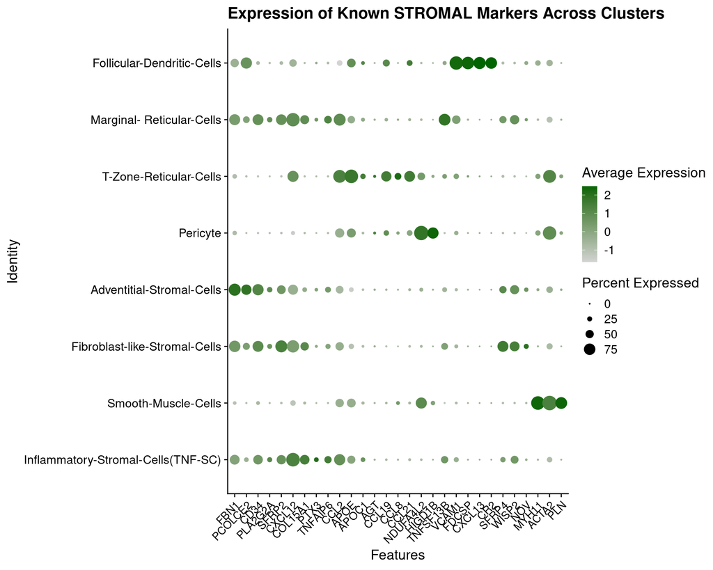

```r
##

stromal_markers <- c("FBN1", "PCOLCE2", "CD34",  "PLA2G2A", "SFRP2","CXCL12", "COL15A1",  "PTX3", "TNFAIP6", "CCL2",  "APOE", "APOC1", "AGT",  "CCL19", "CCL8", "CCL21",  "NDUFA4L2", "HIGD1B",  "TNFSF13B", "VCAM1",  "FDCSP", "CXCL13", "CR2",  "SFRP4", "WISP2", "NOV",  "MYH11", "ACTA2", "PLN")
p=DotPlot(stromal_obj, features = stromal_markers, cols = c("lightgrey", "darkgreen"), group.by = "new_ann") +
  RotatedAxis() + ggtitle("Expression of Known STROMAL Markers Across Clusters") +
  theme(
    axis.text.y = element_text(size = 12),  # increase y-axis text
    axis.text.x = element_text(size = 11)   # optional: increase x-axis text
  )
p
```

```r
#save
ggsave(filename = "output/temp/StromalMarker.png", plot = p, width = 12, height = 8)
```

```r
##save the file and open a new script to remove and keep this to always have the scripts.
#saveRDS(stromal_obj, file = "data/process/temp/stromal_obj.RDS")

## run it later to load all
stromal_obj = readRDS("data/process/temp/stromal_obj.RDS")
```